# Analyzing TMDB movie database

```python
import pandas as pd
import numpy as np
import matplotlib.pyplot as plt
import seaborn as sns
import warnings
warnings.filterwarnings('ignore')
%matplotlib inline
```

## Data Exploration Phase

```python
df = pd.read_csv("tmdb-movies.csv")
```

```python
df.head(5)
```

|  | id | imdb_id | popularity | budget | revenue | original_title | cast | homepage | director | tagline | ... | overview | runtime | genres | production_companies | release_date | vote_count | vote_average | release_year | budget_adj | revenue_adj |
| --- | --- | --- | --- | --- | --- | --- | --- | --- | --- | --- | --- | --- | --- | --- | --- | --- | --- | --- | --- | --- | --- |
| 0 | 135397 | tt0369610 | 32.985763 | 150000000 | 1513528810 | Jurassic World | Chris Pratt\|Bryce Dallas Howard\|Irrfan Khan\|Vi... | http://www.jurassicworld.com/ | Colin Trevorrow | The park is open. | ... | Twenty-two years after the events of Jurassic ... | 124 | Action\|Adventure\|Science Fiction\|Thriller | Universal Studios\|Amblin Entertainment\|Legenda... | 6/9/15 | 5562 | 6.5 | 2015 | 1.379999e+08 | 1.392446e+09 |
| 1 | 76341 | tt1392190 | 28.419936 | 150000000 | 378436354 | Mad Max: Fury Road | Tom Hardy\|Charlize Theron\|Hugh Keays-Byrne\|Nic... | http://www.madmaxmovie.com/ | George Miller | What a Lovely Day. | ... | An apocalyptic story set in the furthest reach... | 120 | Action\|Adventure\|Science Fiction\|Thriller | Village Roadshow Pictures\|Kennedy Miller Produ... | 5/13/15 | 6185 | 7.1 | 2015 | 1.379999e+08 | 3.481613e+08 |
| 2 | 262500 | tt2908446 | 13.112507 | 110000000 | 295238201 | Insurgent | Shailene Woodley\|Theo James\|Kate Winslet\|Ansel... | http://www.thedivergentseries.movie/#insurgent | Robert Schwentke | One Choice Can Destroy You | ... | Beatrice Prior must confront her inner demons ... | 119 | Adventure\|Science Fiction\|Thriller | Summit Entertainment\|Mandeville Films\|Red Wago... | 3/18/15 | 2480 | 6.3 | 2015 | 1.012000e+08 | 2.716190e+08 |
| 3 | 140607 | tt2488496 | 11.173104 | 200000000 | 2068178225 | Star Wars: The Force Awakens | Harrison Ford\|Mark Hamill\|Carrie Fisher\|Adam D... | http://www.starwars.com/films/star-wars-episod... | J.J. Abrams | Every generation has a story. | ... | Thirty years after defeating the Galactic Empi... | 136 | Action\|Adventure\|Science Fiction\|Fantasy | Lucasfilm\|Truenorth Productions\|Bad Robot | 12/15/15 | 5292 | 7.5 | 2015 | 1.839999e+08 | 1.902723e+09 |
| 4 | 168259 | tt2820852 | 9.335014 | 190000000 | 1506249360 | Furious 7 | Vin Diesel\|Paul Walker\|Jason Statham\|Michelle ... | http://www.furious7.com/ | James Wan | Vengeance Hits Home | ... | Deckard Shaw seeks revenge against Dominic Tor... | 137 | Action\|Crime\|Thriller | Universal Pictures\|Original Film\|Media Rights ... | 4/1/15 | 2947 | 7.3 | 2015 | 1.747999e+08 | 1.385749e+09 |

5 rows × 21 columns

```python
df.describe()
```

|  | id | popularity | budget | revenue | runtime | vote_count | vote_average | release_year | budget_adj | revenue_adj |
| --- | --- | --- | --- | --- | --- | --- | --- | --- | --- | --- |
| count | 10866.000000 | 10866.000000 | 1.086600e+04 | 1.086600e+04 | 10866.000000 | 10866.000000 | 10866.000000 | 10866.000000 | 1.086600e+04 | 1.086600e+04 |
| mean | 66064.177434 | 0.646441 | 1.462570e+07 | 3.982332e+07 | 102.070863 | 217.389748 | 5.974922 | 2001.322658 | 1.755104e+07 | 5.136436e+07 |
| std | 92130.136561 | 1.000185 | 3.091321e+07 | 1.170035e+08 | 31.381405 | 575.619058 | 0.935142 | 12.812941 | 3.430616e+07 | 1.446325e+08 |
| min | 5.000000 | 0.000065 | 0.000000e+00 | 0.000000e+00 | 0.000000 | 10.000000 | 1.500000 | 1960.000000 | 0.000000e+00 | 0.000000e+00 |
| 25% | 10596.250000 | 0.207583 | 0.000000e+00 | 0.000000e+00 | 90.000000 | 17.000000 | 5.400000 | 1995.000000 | 0.000000e+00 | 0.000000e+00 |
| 50% | 20669.000000 | 0.383856 | 0.000000e+00 | 0.000000e+00 | 99.000000 | 38.000000 | 6.000000 | 2006.000000 | 0.000000e+00 | 0.000000e+00 |
| 75% | 75610.000000 | 0.713817 | 1.500000e+07 | 2.400000e+07 | 111.000000 | 145.750000 | 6.600000 | 2011.000000 | 2.085325e+07 | 3.369710e+07 |
| max | 417859.000000 | 32.985763 | 4.250000e+08 | 2.781506e+09 | 900.000000 | 9767.000000 | 9.200000 | 2015.000000 | 4.250000e+08 | 2.827124e+09 |

```python
df.info();
```

```
<class 'pandas.core.frame.DataFrame'>
RangeIndex: 10866 entries, 0 to 10865
Data columns (total 21 columns):
id                      10866 non-null int64
imdb_id                 10856 non-null object
popularity              10866 non-null float64
budget                  10866 non-null int64
revenue                 10866 non-null int64
original_title          10866 non-null object
cast                    10790 non-null object
homepage                2936 non-null object
director                10822 non-null object
tagline                 8042 non-null object
keywords                9373 non-null object
overview                10862 non-null object
runtime                 10866 non-null int64
genres                  10843 non-null object
production_companies    9836 non-null object
release_date            10866 non-null object
vote_count              10866 non-null int64
vote_average            10866 non-null float64
release_year            10866 non-null int64
budget_adj              10866 non-null float64
revenue_adj             10866 non-null float64
dtypes: float64(4), int64(6), object(11)
memory usage: 1.7+ MB
```

### Creating a new column that stores the month of release

```python
df["release_month"] = df.release_date.apply(lambda date: date.split('/')[0])
```

```python
df["budget"][df[df["revenue"] == 295238201].index.values.astype(int)[0]]
```

```
110000000
```

## Fixing cast column

```python
cast_revenue = pd.DataFrame()
cast_revenue[["castOne", "castTwo", 'castThree', 'castFour', "castFive"]] = df["cast"].str.split("|", expand=True)
cast_revenue = pd.concat((cast_revenue['castOne'].append(cast_revenue['castTwo'].iloc[:]).reset_index(drop=True),\
           cast_revenue.iloc[:,2:]), ignore_index=True, axis=1)
cast_revenue.columns=["castOne", "castTwo", "castThree", "castFour"]
cast_revenue = pd.concat((cast_revenue['castOne'].append(cast_revenue['castTwo'].iloc[:]).reset_index(drop=True),\
           cast_revenue.iloc[:,2:]), ignore_index=True, axis=1)
cast_revenue.columns=["castOne", "castTwo", "castThree"]
cast_revenue = pd.concat((cast_revenue['castOne'].append(cast_revenue['castTwo'].iloc[:]).reset_index(drop=True),\
           cast_revenue.iloc[:,2:]), ignore_index=True, axis=1)
cast_revenue.columns=["castOne", "castTwo"]
cast_revenue = pd.concat((cast_revenue['castOne'].append(cast_revenue['castTwo'].iloc[:]).reset_index(drop=True),\
           cast_revenue.iloc[:,2:]), ignore_index=True, axis=1)
cast_revenue.columns=["castOne"]
cast_revenue.dropna(inplace=True)
```

```python
cast_revenue.nunique()
```

```
castOne    19026
dtype: int64
```

## Has the number of votes increased over the years?

```python
year_voteCount = df.groupby('release_year').vote_count.sum().reset_index()
columnLabels = ["year", "no_of_votes"]
year_voteCount.columns = columnLabels
year_voteCount.head(5)
```

|  | year | no_of_votes |
| --- | --- | --- |
| 0 | 1960 | 2481 |
| 1 | 1961 | 2405 |
| 2 | 1962 | 2392 |
| 3 | 1963 | 2816 |
| 4 | 1964 | 3137 |

```python
year_voteCount.info()
```

```
<class 'pandas.core.frame.DataFrame'>
RangeIndex: 56 entries, 0 to 55
Data columns (total 2 columns):
year           56 non-null int64
no_of_votes    56 non-null int64
dtypes: int64(2)
memory usage: 976.0 bytes
```

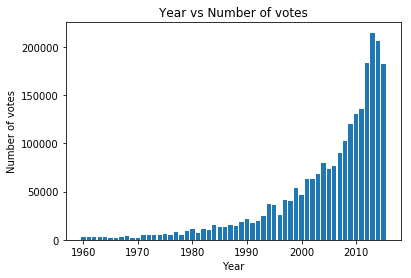

```python
plt.bar(year_voteCount.year,year_voteCount.no_of_votes)
plt.xlabel("Year")
plt.ylabel("Number of votes")
plt.title("Year vs Number of votes")
```

From the above graph, it seems like the number of votes casted upon movies have increased over the years.

## Number of movies released in each month

```python
month_vs_movies = df.groupby("release_month").id.count().reset_index()
month_vs_movies.columns
month_vs_movies.columns=["release_month", "number_movies"]
month_vs_movies["release_month"] = month_vs_movies.release_month.astype(int)
month_vs_movies.sort_values(by=["release_month"], inplace=True)
month_vs_movies
```

|  | release_month | number_movies |
| --- | --- | --- |
| 0 | 1 | 919 |
| 4 | 2 | 691 |
| 5 | 3 | 823 |
| 6 | 4 | 797 |
| 7 | 5 | 809 |
| 8 | 6 | 827 |
| 9 | 7 | 799 |
| 10 | 8 | 918 |
| 11 | 9 | 1331 |
| 1 | 10 | 1153 |
| 2 | 11 | 814 |
| 3 | 12 | 985 |

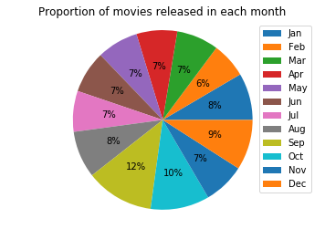

```python
plt.pie(month_vs_movies["number_movies"], autopct="%d%%")
months = ["Jan", "Feb", "Mar", "Apr", "May", "Jun", "Jul", "Aug", "Sep", "Oct", "Nov", "Dec"]
plt.axis('equal')
plt.legend(months)
plt.title("Proportion of movies released in each month")
plt.show()
```

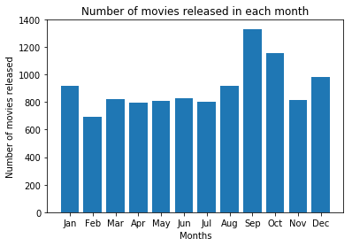

```python
plt.bar(month_vs_movies["release_month"], month_vs_movies["number_movies"])
ax = plt.subplot()
ax.set_xticks(range(1, 13))
ax.set_xticklabels(months)
plt.xlabel("Months")
plt.ylabel("Number of movies released")
plt.title("Number of movies released in each month")
```

From the above bar chart and pie chart it seems like more number of movies were released in september and october. Apart from it all the other months had almost similar range of movies released.

## Relationship between budget and revenue

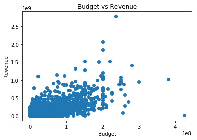

```python
plt.scatter(df["budget"], df["revenue"])
plt.xlabel("Budget")
plt.ylabel("Revenue")
plt.title("Budget vs Revenue")
```

```python
df["budget"].corr(df["revenue"])
```

```
0.7349006819076118
```

There seems to be a positive association between budget and revenue. From the correlation coefficient and the scatter plot, it seems like higher budgets get higher revenue.

## Do more people vote for movies with websites?

```python
df["webpage"] = df.homepage.isnull()
df["webpage"] = ~df["webpage"]
```

```python
web_votes = df.groupby("webpage").vote_count.count()
web_votes
```

```
webpage
False    7930
True     2936
Name: vote_count, dtype: int64
```

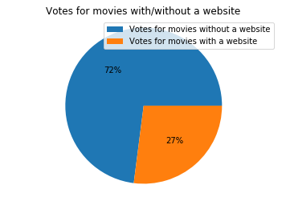

```python
plt.pie(web_votes, autopct="%d%%")
label=["Votes for movies without a website", "Votes for movies with a website"]
plt.legend(label)
plt.axis("equal")
plt.title("Votes for movies with/without a website");
```

## Genres and their popularities

```python
genredf = df[["genres", "popularity", "revenue"]].copy()
genredf[["genreOne", "genreTwo", "genreThree", "genreFour", "genreFive"]] = genredf.genres.str.split("|",expand=True)
genredf.fillna("No Genre", inplace=True)
```

```python
uniqueGenres = list(pd.unique(genredf[["genreOne", "genreTwo", "genreThree", "genreFour", "genreFive"]].values.ravel("K")))
```

```python
mask = genredf.genres.str.contains("Action")
genreMean = genredf[mask].popularity.mean()
```

```python
genre_pop = pd.DataFrame()
for genre in uniqueGenres:
    mask = genredf.genres.str.contains(genre)
    genreMean = genredf[mask].popularity.mean()
    genre_pop.set_value('popularity', genre, genreMean)
```

```python
genre_popx = genre_pop.transpose()
genre_popx["genre"] = genre_popx.index
```

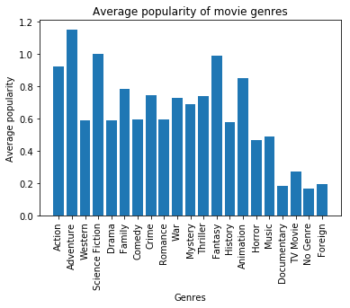

```python
plt.bar(range(len(genre_popx)), genre_popx["popularity"])
ax = plt.subplot()
ax.set_xticks(range(len(genre_popx)))
ax.set_xticklabels(genre_popx["genre"], rotation=90)
plt.title("Average popularity of movie genres")
plt.xlabel("Genres")
plt.ylabel("Average popularity");
```

From the above bar chart, it can be seen, movies in adventure genre received the highest popularity among viewers.

## Revenues of genres

```python
genreRev = pd.DataFrame()
for genre in uniqueGenres:
    mask = genredf.genres.str.contains(genre)
    genreMean = genredf[mask].revenue.mean()
    genreRev.set_value('revenue', genre, genreMean)
```

```python
genreRev = genreRev.transpose()
genreRev["genre"] = genreRev.index
```

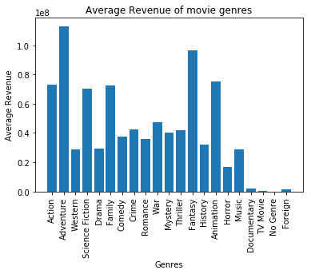

```python
plt.bar(range(len(genreRev)), genreRev["revenue"])
ax = plt.subplot()
ax.set_xticks(range(len(genreRev)))
ax.set_xticklabels(genreRev["genre"], rotation=90)
plt.title("Average Revenue of movie genres")
plt.xlabel("Genres")
plt.ylabel("Average Revenue");
```

From the above bar chart it seems like adventure and fantasy genres have earned more revenue compared to others.

## Runtime vs Budget

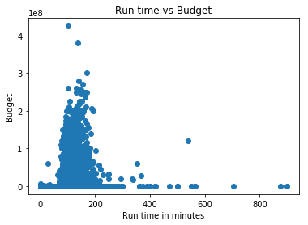

```python
plt.scatter(df["runtime"], df["budget"])
plt.xlabel("Run time in minutes")
plt.ylabel("Budget")
plt.title("Run time vs Budget")
```

```python
df["runtime"].corr(df.budget)
```

```
0.19128265656578047
```

From the above scatter plot and the correlation coefficient, there seems to be no linear relationship between run time and budget. Budget doesnt seem to increase with run time.

## Runtime vs Revenue

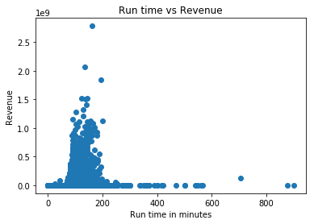

```python
plt.scatter(df["runtime"], df["revenue"])
plt.xlabel("Run time in minutes")
plt.ylabel("Revenue")
plt.title("Run time vs Revenue")
```

```python
df["runtime"].corr(df.revenue)
```

```
0.16283788998268608
```

From the above scatter plot and correlation coefficient, it seems like there is no linear relationship between run time and revenue

## Do movies with websites earn more revenue

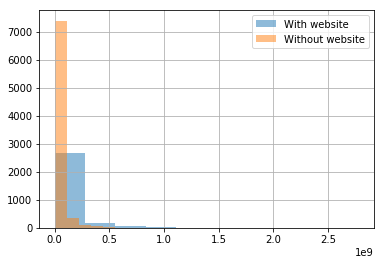

```python
loss = df.budget > df.revenue
profit = df.revenue > df.budget
website = df.webpage == True
nowebsite = df.webpage == False

df.revenue[website].hist(alpha=0.5, label="With website")
df.revenue[nowebsite].hist(alpha=0.5, label="Without website")
plt.legend()
plt.xlabel()
```

From the above histogram, it seems like movies making more revenue had websites

## Do movies with higher popularity earn profits much more than movies with lesser popularity?

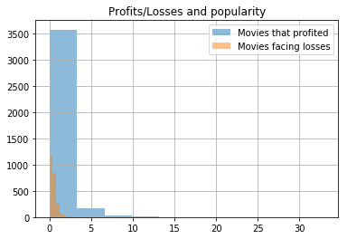

```python
df.popularity[profit].hist(alpha=0.5, label="Movies that profited")
df.popularity[loss].hist(alpha=0.5, label="Movies facing losses")
plt.legend()
plt.title("Profits/Losses and popularity")
```

From the above histogram, it seems like movies that were profitting had more popularity compared to movies that were facing losses.